# Clark-Izzi-ADA-Homework-4

# CHALLENGE 1

Plot global data on confirmed coronavirus infections, deaths, and recoveries. (Faceted by variable rather than country, although it doesn’t really matter in this case.)

```
## $totals
## # A tibble: 6 x 8
##   country variable          cases population      area density   rate on
##   <chr>   <chr>             <dbl>      <dbl>     <dbl>   <dbl>  <dbl> <date>
## 1 World   confirmed       4100108 7525907933    1.27e8    59.4 545.   2020-05-10
## 2 World   daily_confirmed   99113 7525907933    1.27e8    59.4  13.2  2020-05-10
## 3 World   daily_deaths       8856 7525907933    1.27e8    59.4   1.18 2020-05-10
## 4 World   daily_recovered   65439 7525907933    1.27e8    59.4   8.70 2020-05-10
## 5 World   deaths           282666 7525907933    1.27e8    59.4  37.6  2020-05-10
## 6 World   recovered       1407676 7525907933    1.27e8    59.4 187.   2020-05-10
##
## $cum_cases_plot
```

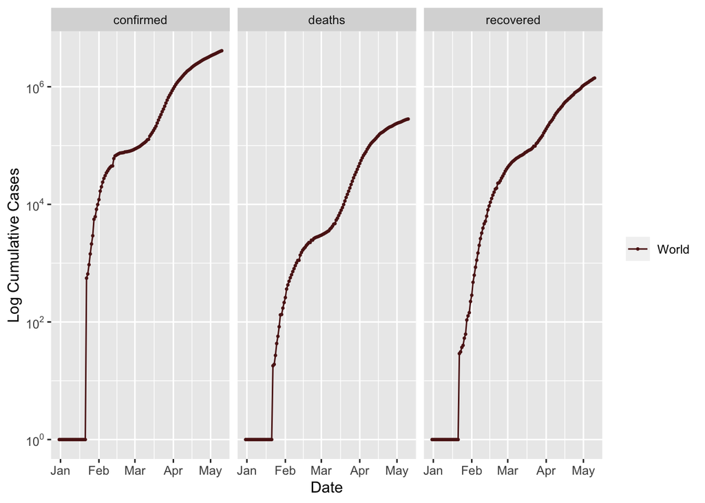

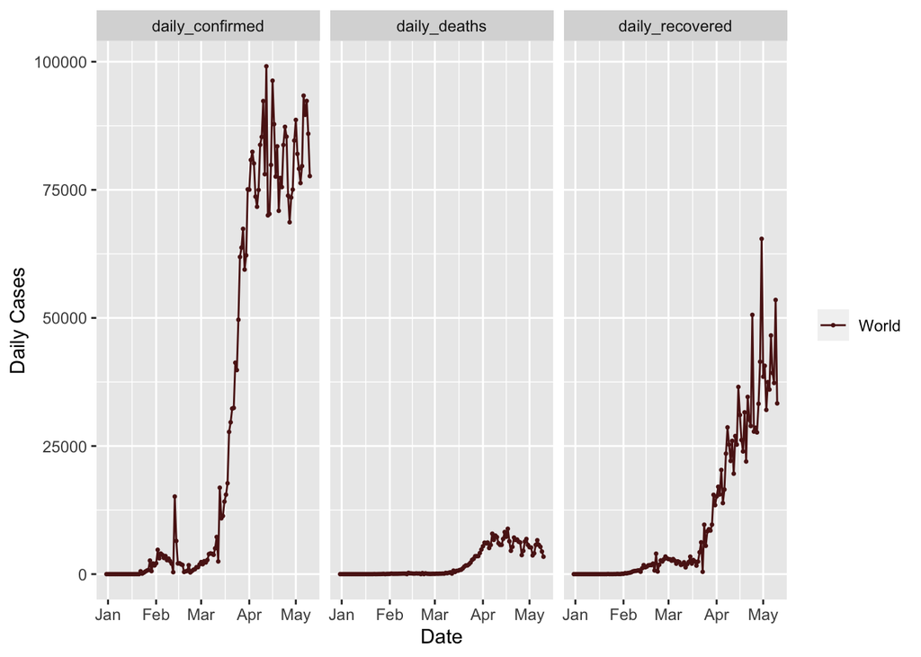

```r
cv_summary(cv_data, country_list = "World", plot = TRUE, facet = "variable")
```

# CHALLENGE 2

Plot data on confirmed coronavirus infections, deaths, and recoveries for G7 countries plus China, Russia, and Iran. Facet your plots first by “country” and then by “variable”.

```
## $totals
## # A tibble: 60 x 13
##    country variable cases population   area density    rate gdp_capita income
##    <chr>   <chr>    <dbl>      <dbl>  <dbl>   <dbl>   <dbl>      <dbl> <chr>
##  1 Canada  confirm… 70091   37057765 9.09e6    4.08 1.89e+3     51392. High …
##  2 Canada  daily_c…  2778   37057765 9.09e6    4.08 7.50e+1     51392. High …
##  3 Canada  daily_d…   251   37057765 9.09e6    4.08 6.77e+0     51392. High …
##  4 Canada  daily_r…  1385   37057765 9.09e6    4.08 3.74e+1     51392. High …
##  5 Canada  deaths    4991   37057765 9.09e6    4.08 1.35e+2     51392. High …
##  6 Canada  recover… 32109   37057765 9.09e6    4.08 8.66e+2     51392. High …
##  7 China   confirm… 84010 1392730000 9.39e6  148.   6.03e+1      7753. Upper…
##  8 China   daily_c… 15136 1392730000 9.39e6  148.   1.09e+1      7753. Upper…
##  9 China   daily_d…  1290 1392730000 9.39e6  148.   9.26e-1      7753. Upper…
## 10 China   daily_r…  3995 1392730000 9.39e6  148.   2.87e+0      7753. Upper…
## # … with 50 more rows, and 4 more variables: life_expectancy <dbl>,
## #   max_sd <dbl>, max_mr <dbl>, on <date>
##
## $cum_cases_plot
```

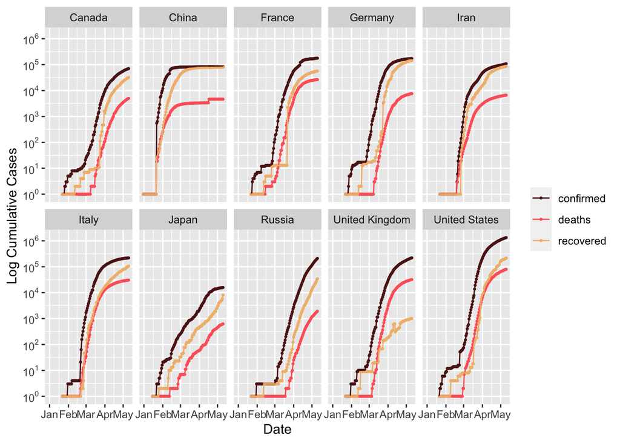

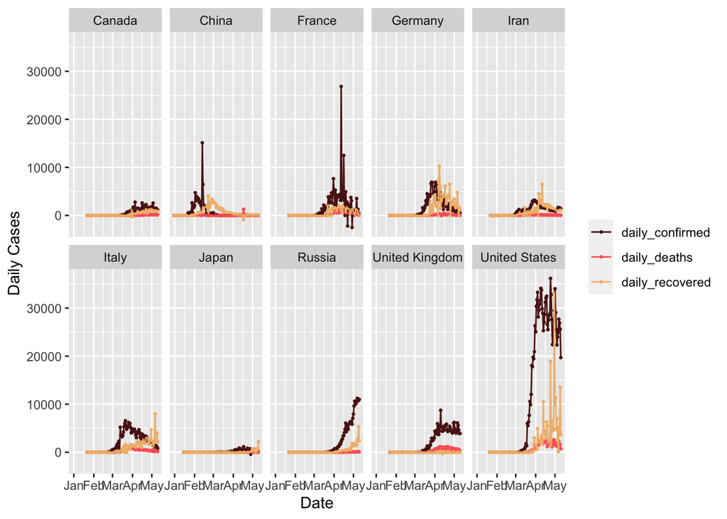

```r
cv_summary(cv_data, country_list = c("United States", "United Kingdom", "Canada", "France", "Germany", "Italy", "Japan", "China", "Russia", "Iran"), plot = TRUE, facet = "country")
```

```
## $totals
## # A tibble: 60 x 13
##    country variable cases population   area density    rate gdp_capita income
##    <chr>   <chr>    <dbl>      <dbl>  <dbl>   <dbl>   <dbl>      <dbl> <chr>
##  1 Canada  confirm… 70091   37057765 9.09e6    4.08 1.89e+3     51392. High …
##  2 Canada  daily_c…  2778   37057765 9.09e6    4.08 7.50e+1     51392. High …
##  3 Canada  daily_d…   251   37057765 9.09e6    4.08 6.77e+0     51392. High …
##  4 Canada  daily_r…  1385   37057765 9.09e6    4.08 3.74e+1     51392. High …
##  5 Canada  deaths    4991   37057765 9.09e6    4.08 1.35e+2     51392. High …
##  6 Canada  recover… 32109   37057765 9.09e6    4.08 8.66e+2     51392. High …
##  7 China   confirm… 84010 1392730000 9.39e6  148.   6.03e+1      7753. Upper…
##  8 China   daily_c… 15136 1392730000 9.39e6  148.   1.09e+1      7753. Upper…
##  9 China   daily_d…  1290 1392730000 9.39e6  148.   9.26e-1      7753. Upper…
## 10 China   daily_r…  3995 1392730000 9.39e6  148.   2.87e+0      7753. Upper…
## # … with 50 more rows, and 4 more variables: life_expectancy <dbl>,
## #   max_sd <dbl>, max_mr <dbl>, on <date>
##
## $cum_cases_plot
```

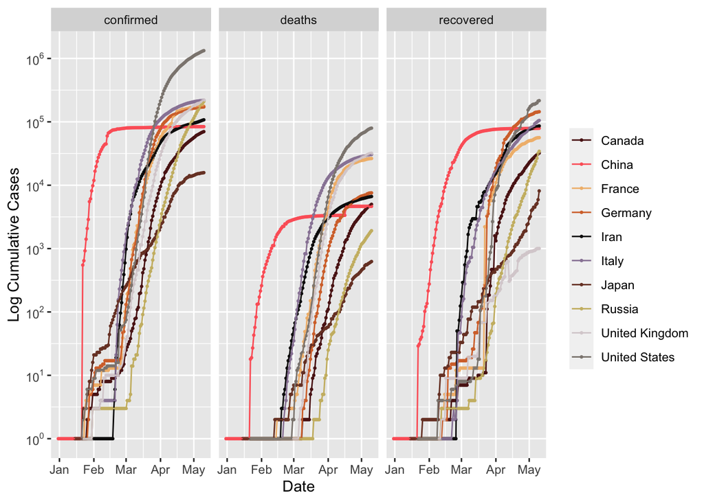

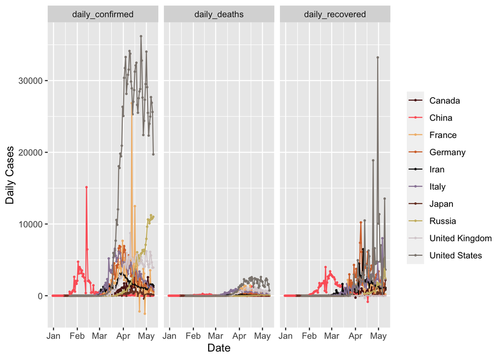

```r
cv_summary(cv_data, country_list = c("United States", "United Kingdom", "Canada", "France", "Germany", "Italy", "Japan", "China", "Russia", "Iran"), plot = TRUE, facet = "variable")
```

# CHALLENGE 3

Summary data for ALL countries in the dataset, then filter dataset to only those countries with populations of over 1 million. How many countries does this tibble include?

(But it was 918 then 924 as of May 14?)

```r
summ <- cv_summary(cv_data, country_list = "All", plot = FALSE)
d <- summ$totals # since tibble is outputted in list of one element
d <- filter(d, population > 1000000)
nrow(d)
```

```
## [1] 930
```

# CHALLENGE 4

Which 10 countries have experienced the highest single-day rate of confirmed cases? See below:

```r
# OVERALL CONFIRMED CASES
overall <- filter(d, variable == "confirmed") %>% arrange(desc(rate))
## Top 10:
top_n(overall, 10, rate)$country
```

```
##  [1] "Qatar"          "Spain"          "Ireland"        "Belgium"
##  [5] "Singapore"      "United States"  "Italy"          "Switzerland"
##  [9] "United Kingdom" "Bahrain"
```

```r
# DAILY CONFIRMED
daily <- filter(d, variable == "daily_confirmed", rate > 0) %>% arrange(desc(rate))
## Top 10:
top_n(daily, 10, rate)$country
```

```
##  [1] "Ecuador"   "Qatar"     "France"    "Ireland"   "Kuwait"    "Singapore"
##  [7] "Belgium"   "Bahrain"   "Spain"     "Belarus"
```

# CHALLENGE 5

gdp_capita has a slope significantly different from 0 (P = 0.000326)  
Note: Density was significant when I filtered out 0’s and used log() instead of log1p(), but it’s p-value increased to 0.0866 here when I did it this way.

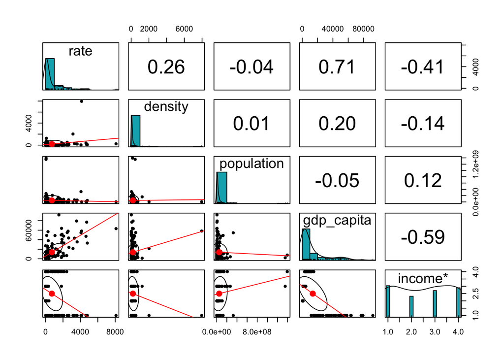

```r
# visualize distribution and scatterplots using {psych}
library(psych)
x <- select(overall, c("rate", "density","population","gdp_capita","income"))
pairs.panels(x[],
  smooth = FALSE,
  lm = TRUE,
  method = "pearson",
  hist.col = "#00AFBB",
  density = TRUE,
  ellipses = TRUE
)
```

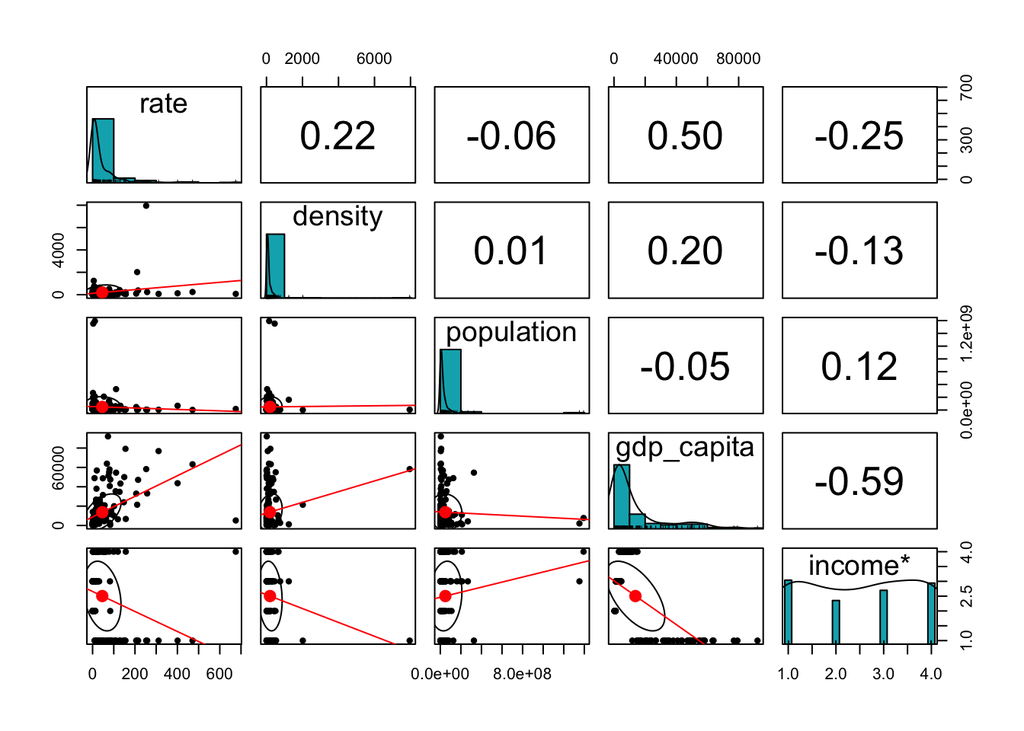

```r
# DAILY
y <- select(daily, c("rate", "density", "population", "gdp_capita", "income"))
pairs.panels(y[],
  smooth = FALSE,
  lm = TRUE,
  method = "pearson",
  hist.col = "#00AFBB",
  density = TRUE,
  ellipses = TRUE
)
```

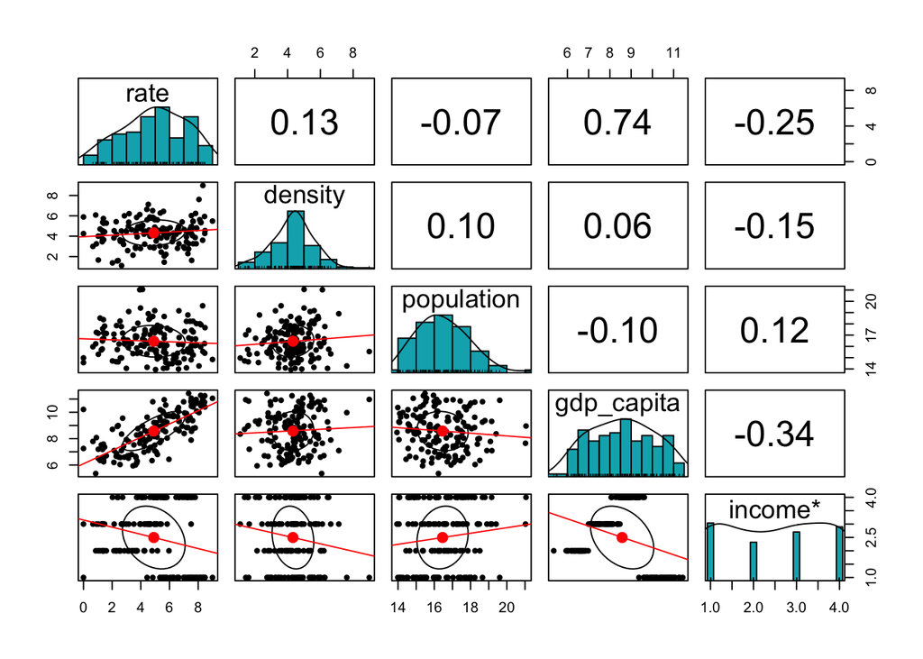

```r
# Continuous variables are not normally distributed, so log transform rate, density, population, gdp_capita in new tibble overall_log
overall_log <- tibble(rate = log1p(overall$rate), density = log1p(overall$density), population = log1p(overall$population), gdp_capita = log1p(overall$gdp_capita), income = overall$income)
# same for daily, which we'll use later
daily_log <- tibble(rate = log1p(daily$rate), density = log1p(daily$density), population = log1p(daily$population), gdp_capita = log1p(daily$gdp_capita), income = daily$income)
# visualize overall again - yay normal distribution!
pairs.panels(overall_log,
  smooth = FALSE,
  lm = TRUE,
  method = "pearson",
  hist.col = "#00AFBB",
  density = TRUE,
  ellipses = TRUE
)
```

```r
# FULL MODEL USING OVERALL_LOG
m_full <- lm(rate ~ density + population + gdp_capita + income, data = overall_log)
summary(m_full)
```

```
##
## Call:
## lm(formula = rate ~ density + population + gdp_capita + income,
##     data = overall_log)
##
## Residuals:
##     Min      1Q  Median      3Q     Max
## -6.9433 -0.7922  0.1078  0.9493  3.6487
##
## Coefficients:
##                            Estimate Std. Error t value Pr(>|t|)
## (Intercept)               -4.680015   3.079635  -1.520 0.130788
## density                    0.166700   0.096604   1.726 0.086564 .
## population                 0.007788   0.087639   0.089 0.929314
## gdp_capita                 1.030219   0.279780   3.682 0.000326 ***
## incomeLow income           0.090224   1.166401   0.077 0.938451
## incomeLower middle income -0.508877   0.836423  -0.608 0.543883
## incomeUpper middle income  0.138464   0.537358   0.258 0.797025
## ---
## Signif. codes:  0 '***' 0.001 '**' 0.01 '*' 0.05 '.' 0.1 ' ' 1
##
## Residual standard error: 1.478 on 144 degrees of freedom
##   (4 observations deleted due to missingness)
## Multiple R-squared:  0.5607, Adjusted R-squared:  0.5424
## F-statistic: 30.64 on 6 and 144 DF,  p-value: < 2.2e-16
```

```r
detach(package:psych)
```

# CHALLENGE 6

## Best model: rate ~ density + gdp_capita

(although AIC is not quite 2 less than density + population + gdp_capita)  
## Pseudo-R2 - Full: 0.55, Best: 0.54 Which doesn’t really make sense - shouldn’t the best model have a higher value? Earlier on I got Full: 0.515, Best: 0.546, but then I guess I fiddled with filtering NA’s and 0’s and when I ran everything again got these results instead. Tried to backtrack and figure out what caused the difference, but haven’t been able to replicate those orignal results.

```r
library(MASS)
library(MuMIn)
s <- stepAIC(m_full, scope = .~., direction = "both")
```

```
## Start:  AIC=124.77
## rate ~ density + population + gdp_capita + income
##
##              Df Sum of Sq    RSS    AIC
## - population  1    0.0172 314.47 122.78
## - income      3    9.2052 323.66 123.12
## <none>                    314.45 124.77
## - density     1    6.5024 320.96 125.86
## - gdp_capita  1   29.6088 344.06 136.35
##
## Step:  AIC=122.78
## rate ~ density + gdp_capita + income
##
##              Df Sum of Sq    RSS    AIC
## - income      3    9.2051 323.68 121.13
## <none>                    314.47 122.78
## - density     1    6.6963 321.17 123.96
## + population  1    0.0172 314.45 124.77
## - gdp_capita  1   30.3965 344.87 134.71
##
## Step:  AIC=121.13
## rate ~ density + gdp_capita
##
##              Df Sum of Sq    RSS    AIC
## <none>                    323.68 121.13
## - density     1      6.02 329.69 121.91
## + income      3      9.21 314.47 122.78
## + population  1      0.02 323.66 123.12
## - gdp_capita  1    379.38 703.06 236.26
```

```r
m_best <- lm(rate ~ density + gdp_capita, data = overall_log)
summary(m_best)
```

```
##
## Call:
## lm(formula = rate ~ density + gdp_capita, data = overall_log)
##
## Residuals:
##     Min      1Q  Median      3Q     Max
## -6.9362 -0.7510  0.1578  0.9808  3.3395
##
## Coefficients:
##             Estimate Std. Error t value Pr(>|t|)
## (Intercept) -4.93249    0.79922  -6.172 6.16e-09 ***
## density      0.15715    0.09475   1.659   0.0993 .
## gdp_capita   1.07115    0.08133  13.171  < 2e-16 ***
## ---
## Signif. codes:  0 '***' 0.001 '**' 0.01 '*' 0.05 '.' 0.1 ' ' 1
##
## Residual standard error: 1.479 on 148 degrees of freedom
##   (4 observations deleted due to missingness)
## Multiple R-squared:  0.5479, Adjusted R-squared:  0.5417
## F-statistic: 89.66 on 2 and 148 DF,  p-value: < 2.2e-16
```

```r
# Pseudo-R^2
r.squaredGLMM(m_full)
```

```
##            R2m       R2c
## [1,] 0.5506573 0.5506573
```

```r
r.squaredGLMM(m_best)
```

```
##            R2m       R2c
## [1,] 0.5445259 0.5445259
```

Repeat this modeling process to evaluate what combination of explanatory variables best predict maximum daily infection rate. Are the important predictors the same? What additional or different variables are included?  
## Best model: rate ~ density + population + gdp_capita  
## Population size becomes an important predictor in daily infection rate.

```r
m_daily <- lm(rate ~ density + population + gdp_capita + income, data = daily_log)
(s <- stepAIC(m_daily, scope = .~., direction = "both"))
```

```
## Start:  AIC=15.44
## rate ~ density + population + gdp_capita + income
##
##              Df Sum of Sq    RSS    AIC
## - income      3    3.8440 154.29 13.195
## <none>                    150.44 15.436
## - density     1    4.1951 154.64 17.534
## - population  1    6.7839 157.23 20.008
## - gdp_capita  1   16.5730 167.02 29.007
##
## Step:  AIC=13.2
## rate ~ density + population + gdp_capita
##
##              Df Sum of Sq    RSS     AIC
## <none>                    154.29  13.195
## + income      3     3.844 150.44  15.436
## - density     1     4.579 158.87  15.553
## - population  1     8.299 162.59  19.001
## - gdp_capita  1   171.602 325.89 122.609
```

```
##
## Call:
## lm(formula = rate ~ density + population + gdp_capita, data = daily_log)
##
## Coefficients:
## (Intercept)      density   population   gdp_capita
##     -1.3548       0.1387      -0.1687       0.7291
```

```r
detach(package:MASS)
```

# CHALLENGE 7

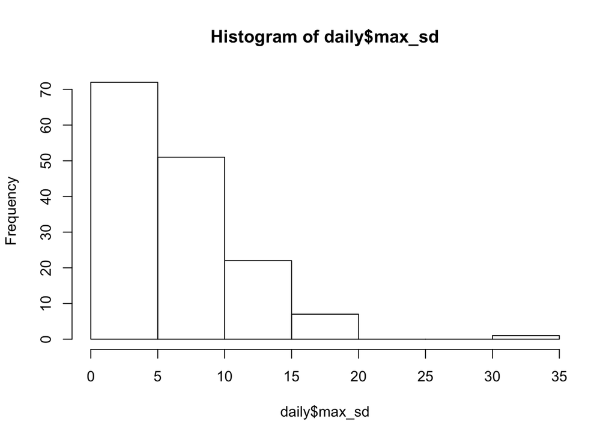

```r
# check whether new variables should be transformed - they should
hist(daily$max_sd)
```

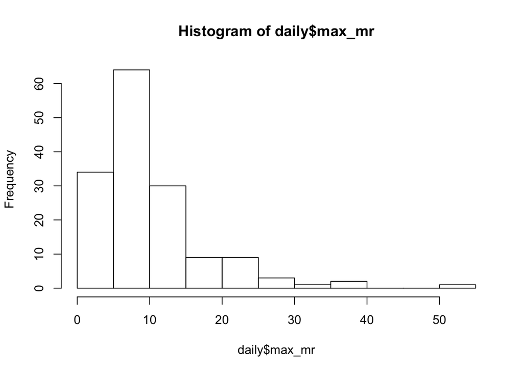

```r
hist(daily$max_mr)
```

```r
# generate possible models with addition of max_mr, max_sd, or both
daily_log <- add_column(daily_log, max_sd = log1p(daily$max_sd), max_mr = log1p(daily$max_mr))
best_daily <- lm(rate ~ density + population + gdp_capita, data = daily_log)
best_SD_MR <- lm(rate ~ density + population + gdp_capita + max_sd + max_mr, data = daily_log)
best_SD <- lm(rate ~ density + population + gdp_capita + max_sd, data = daily_log)
best_MR <- lm(rate ~ density + population + gdp_capita + max_mr, data = daily_log)
# AIC table to compare new models to original best
library(AICcmodavg)
(aic_table <- aictab(list(best_daily, best_SD_MR, best_SD, best_MR), modnames = c("best_daily", "best_SD_MR", "best_SD", "best_MR")))
```

```
##
## Model selection based on AICc:
##
##            K   AICc Delta_AICc AICcWt Cum.Wt      LL
## best_daily 5 438.46       0.00   0.49   0.49 -214.02
## best_MR    6 439.87       1.41   0.24   0.73 -213.64
## best_SD    6 440.50       2.04   0.18   0.91 -213.95
## best_SD_MR 7 441.86       3.40   0.09   1.00 -213.53
```

```r
# alternative(?): use add1() to see if p_values of max_sd or max_mr are significant, which they are not
add1(best_daily, scope = .~. + max_sd + max_mr, test = "F")
```

```
## Single term additions
##
## Model:
## rate ~ density + population + gdp_capita
##        Df Sum of Sq    RSS    AIC F value Pr(>F)
## <none>              154.29 13.195
## max_sd  1   0.13639 154.15 15.064  0.1274 0.7217
## max_mr  1   0.78334 153.50 14.437  0.7348 0.3927
```

# CHALLENGE 8

The best mixed effects model is the full model, containing all 4 fixed effects (log(density), log(gdp_capita), soc_dist, mov_rest) along with random effects country and date.  
Its pseudo-R^2 is 0.519 (conditional - variance explained by fixed and random effects), and 0.279 (marginal - variance explained by fixed effects only).

```r
library(lme4)
# filter cv_data
cv_filtered <- filter(cv_data, population > 1000000, variable == "daily_confirmed", rate > 0)
# full model
m1 <- lmer(rate ~ log(density) + log(gdp_capita) + soc_dist + mov_rest + (1|country) + (1|date), data = cv_filtered, REML = FALSE)
# 3 fixed effects
minusMR <- lmer(rate ~ log(density) + log(gdp_capita) + soc_dist + (1|country) + (1|date), data = cv_filtered, REML = FALSE)
minusSD <- lmer(rate ~ log(density) + log(gdp_capita) + mov_rest + (1|country) + (1|date), data = cv_filtered, REML = FALSE)
minusGDP <- lmer(rate ~ log(density) + soc_dist + mov_rest + (1|country) + (1|date), data = cv_filtered, REML = FALSE)
minusDen <- lmer(rate ~ log(gdp_capita) + soc_dist + mov_rest + (1|country) + (1|date), data = cv_filtered, REML = FALSE)
# 2 fixed effects
Den_GDP <- lmer(rate ~ log(density) + log(gdp_capita) + (1|country) + (1|date), data = cv_filtered, REML = FALSE)
Den_SD <- lmer(rate ~ log(density) + soc_dist + (1|country) + (1|date), data = cv_filtered, REML = FALSE)
Den_MR <- lmer(rate ~ log(density) + mov_rest + (1|country) + (1|date), data = cv_filtered, REML = FALSE)
GDP_SD <- lmer(rate ~ log(gdp_capita) + soc_dist + (1|country) + (1|date), data = cv_filtered, REML = FALSE)
GDP_MR <- lmer(rate ~ log(gdp_capita) + mov_rest + (1|country) + (1|date), data = cv_filtered, REML = FALSE)
SD_MR <- lmer(rate ~ soc_dist + mov_rest + (1|country) + (1|date), data = cv_filtered, REML = FALSE)
# 1 fixed effect
mDen <- lmer(rate ~ log(density) + (1|country) + (1|date), data = cv_filtered, REML = FALSE)
mGDP <- lmer(rate ~ log(gdp_capita) + (1|country) + (1|date), data = cv_filtered, REML = FALSE)
mSC <- lmer(rate ~ soc_dist + (1|country) + (1|date), data = cv_filtered, REML = FALSE)
mMR <- lmer(rate ~ mov_rest + (1|country) + (1|date), data = cv_filtered, REML = FALSE)
# null model - random effects only
null <- lmer(rate ~ (1|country) + (1|date), data = cv_filtered, REML = FALSE)

# AIC table
library(AICcmodavg)
(aic_table <- aictab(list(m1, minusMR, minusSD, minusGDP, minusDen, Den_GDP, Den_SD, Den_MR, GDP_SD, GDP_MR, SD_MR, mDen, mGDP, mSC, mMR, null), modnames = c("full", "minusMR", "minusSD", "minusGDP", "minusDen", "Den_GDP", "Den_SD", "Den_MR", "GDP_SD", "GDP_MR", "SD_MR", "Den", "GDP", "SD", "MR", "null")
))
```

```
##
## Model selection based on AICc:
##
##          K     AICc Delta_AICc AICcWt Cum.Wt        LL
## full     8 71438.64       0.00   0.99   0.99 -35711.31
## minusMR  7 71449.07      10.43   0.01   1.00 -35717.53
## minusDen 7 71845.40     406.76   0.00   1.00 -35915.69
## GDP_SD   6 71855.14     416.50   0.00   1.00 -35921.56
## minusGDP 7 71877.99     439.35   0.00   1.00 -35931.99
## Den_SD   6 71884.89     446.25   0.00   1.00 -35936.44
## minusSD  7 71957.96     519.32   0.00   1.00 -35971.97
## Den_GDP  6 71981.03     542.39   0.00   1.00 -35984.51
## SD_MR    6 72286.38     847.74   0.00   1.00 -36137.19
## SD       5 72292.68     854.04   0.00   1.00 -36141.34
## GDP_MR   6 72368.26     929.62   0.00   1.00 -36178.13
## GDP      5 72389.85     951.21   0.00   1.00 -36189.92
## Den_MR   6 72433.14     994.50   0.00   1.00 -36210.57
## MR       5 72843.21    1404.57   0.00   1.00 -36416.60
## Den      5 73357.08    1918.44   0.00   1.00 -36673.54
## null     4 73765.67    2327.03   0.00   1.00 -36878.83
```

```r
# Pseudo-R^2
r.squaredGLMM(m1)
```

```
##            R2m       R2c
## [1,] 0.2788334 0.5187127
```

```r
detach(package:lme4)
detach(package:AICcmodavg)
detach(package:MuMIn)
```